# Introduction

Every day, more than 80,000 commercial flights take place around the world, operated by hundreds of airlines. For all aircraft take-off weight exceeding 27 tons, a regulatory constraint requires companies to systematically record and analyse all flight data, for the purpose of improving the safety of flights. Flight Data Monitoring strive to detect and prioritize deviations from standards set by the aircraft manufacturers, the authorities of civil aviation in the country, or even companies themselves. Such deviations, called events, are used to populate a database that enables companies to identify and monitor the risks inherent in these operations.

This notebook is designed to let you manipulate real aeronautical data, provided by the Safran Group. It is divided in two parts: the first part deals with the processing of raw data, i.e. to perform pre-processing and visualizations needed to understand and clean the data. The second part deals with actual data analysis, and covers many interesting problems.

# Part 1: Data processing

# 1.1 Loading data

Load the RAW data into the structure proposed below (the schema is given to you), using the code provided. The definition of the variables available is given here:

- T: time (Hz)
- LATP_1: Latitude (°)
- LONP_1: Longitude (°)
- RALT1: Radio Altitude, sensor 1 (feet)
- RALT2: Radio Altitude, sensor 2 (feet)
- RALT3: Radio Altitude, sensor 3 (feet)
- ALT_STD: Relative Altitude (feet)
- HEAD: head (°)
- PITCH: pitch (°)
- ROLL: roll (°)
- MACH: Mach (Mach) number
- IAS: Tentative Air Speed (m/s)
- N11 : speed N1 of the first engine (% of tr/min)
- N21 : speed N2 of the second engine (% of tr/min)
- N12 : speed N1 of the second engine (% of tr/min)
- N22 : speed N2 of the second engine (% of tr/min)
- AIR_GROUND: status in the air (Boolean)
- AP_ENGAGED: active Autopilot mode (Boolean)
- AP_OFF: Autopilot off (Boolean)

**Note**: The time unit of variable T is 8Hz. If you want to obtain the time in seconds, you need to divide this varible by 8.

```python
import csv
import numpy as np
from os import listdir
from os.path import isfile, join
BASE_DIR = "/safran/"

#fonction de chargement des données
def load_data_from_directory(DATA_PATH):
    files_list = [f for f in listdir(DATA_PATH) if isfile(join(DATA_PATH, f))]
    Fe = 1
    flight_list = list()

    print("There are %d files in total" % len(files_list))

    # we only load data of the first 390 files
    max_flight = 390
    print("We process %d files" % max_flight)

    for ind_file,afile in enumerate(files_list):
        flight_list_struct = {}
        # print the percentages to keep track the process status
        if np.mod(ind_file,max_flight/10)==0:
            print(np.round(float(ind_file)/float(max_flight)*100),'%')

        # only process the first "max_flight" files
        if ind_file <max_flight:
            variables_names = list()
            data_dictionary = {}
            mask_dictionary = {}
            file=open(join(DATA_PATH,afile), 'r')
            csv_file=csv.reader(file,delimiter=',')
            for ind_row,row in enumerate(csv_file):
                # extract the header and initialize "columns"
                if ind_row==0:
                    variables_names = row
                    for id_var,var_name in enumerate(variables_names):
                        data_dictionary[var_name]=list()
                        mask_dictionary[var_name]=list()
                else:
                    for id_var,var_name in enumerate(variables_names):
                        try:
                            # get the value at the current column
                            a = row[id_var]
                            # append the value to the corresponding column
                            data_dictionary[var_name].append(float(a))
                            # mark the value is correct
                            mask_dictionary[var_name].append(1)
                        except:
                            # if the value is empty (missing value)
                            if a=='':
                                data_dictionary[var_name].append(-1)
                            # if the value can not be converted to float
                            else:
                                data_dictionary[var_name].append(a)
                            # mark the value is incorrect
                            mask_dictionary[var_name].append(0)
            # to get good performance in processing
            # we convert the list values in each column to a numpy array
            for id_var,var_name in enumerate(variables_names):
                data_dictionary[var_name]=np.array(data_dictionary[var_name])
                mask_dictionary[var_name]=np.array(mask_dictionary[var_name],dtype=bool)

            flight_list_struct['DATA']=data_dictionary
            flight_list_struct['MASK']=mask_dictionary
            file.close()
        else:
            break

        # the data of each file is stored in seperated data structures, which are simple list
        flight_list.append(flight_list_struct)
    print('data loaded')
    return flight_list,variables_names
```

```python
DATA_PATH = BASE_DIR + "TP_part1/"
flight_list,variables_names = load_data_from_directory(DATA_PATH)
max_flight = len(flight_list)
```

```
There are 788 files in total
We process 390 files
0.0 %
10.0 %
20.0 %
30.0 %
40.0 %
50.0 %
60.0 %
70.0 %
80.0 %
90.0 %
100.0 %
data loaded
```

The data structure is a list of the flights, which contains all of the necessary data for the notebook. Each item in the list is divided into two parts: a part 'DATA', which contains a dictionary, where each key is a vector of values, and a 'MASK' part, which contains the same dictionary but the data attached to each key is a vector of Boolean that indicates whether or not the value is correct. For example:

```python
print(flight_list[0]['DATA']['N22'])
```

```
[ 60.63  60.63  60.63 ...,  58.75  58.75  58.75]
```

contains the vector of all values of the parameter N22, for flight at index 0. Similarly,

```python
print(flight_list[0]['MASK']['N22'])
```

```
[ True  True  True ...,  True  True  True]
```

contains the vector of Booleans that corresponds to the validity of the parameter. This Boolean can be used to subsequently invalidate the outliers in the subsequent stages of filtering, that we will perform next. Below is the set of variables that constitute our schema.

```python
print(flight_list[0]['DATA'].keys())
```

```
dict_keys(['T', 'AP_OFF', 'ALT_STD', 'LONP_1', 'IAS', 'RALT2', 'HEAD', 'AP_ENGAGED', 'N12', 'ROLL', 'RALT3', 'MACH', 'N21', 'LATP_1', 'PITCH', 'RALT1', 'N22', 'AIR_GROUND', 'N11'])
```

## 1.2 Visualisation

To perform monitoring of flights, it is necessary to clean up the data. To start, it is important to visualize the data that is available, in order to understand better their properties and the problems associated with them (noise, statistical characteristics, ladders, features and other values).

**Question**: For an arbitrary flight, visualize the available variables.

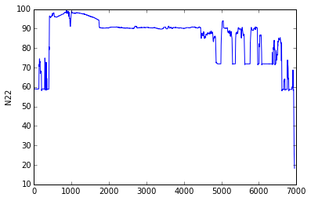

```python
%matplotlib inline
import matplotlib
import matplotlib.pyplot as plt

def plotDataByIndex(index,dataMask,key):
    plt.plot(flight_list[index][dataMask][key])
    plt.ylabel(key)
    plt.show()

plotDataByIndex(50,'DATA','N22')
```

If it is interesting to see the variables for a given flight, it is more informative to view the set of values for all flights in order to understand what are the significant/normal values and what are those which are abnormal.

**Question**: For the N21 variable, for example, display all of the flights on the same figure. Submit a visualization to make the difference between common and atypical values.

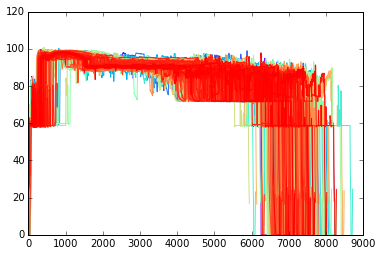

```python
%matplotlib inline
import matplotlib
import matplotlib.pyplot as plt
import matplotlib.cm as cm
def plotData(dataMask,key):
    colors = iter(cm.rainbow(np.linspace(0, 1, len(flight_list))))

    for y in flight_list:
        x = [i for i in range(0,len(y[dataMask][key]))]
        plt.plot(x,y[dataMask][key], color=next(colors))



plotData('DATA','N21')
```

Some variables must be analyzed together, such as latitude and longitude, otherwise the analysis information will be highly incomplete.

**Question**: Display the subset of trajectories (latitude, longitude) from different flights that are available. What do you see?

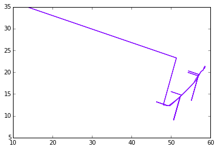

```python
%matplotlib inline
import matplotlib
import matplotlib.pyplot as plt
import matplotlib.cm as cm

def plotMovement(index,dataMask,latp='LATP_1',long='LONP_1'):
        colors = iter(cm.rainbow(np.linspace(0, 1, len(flight_list))))

        x = [i for i in flight_list[index][dataMask][latp] ]
        y = [i for i in flight_list[index][dataMask][long] ]
        plt.plot(x,y, color=next(colors))



plotMovement(1,'DATA')
plotMovement(20,'DATA')
plotMovement(10,'DATA')
```

Remind that our goal is to understand the nature and the inherent problems of our data, and its features. Proceed with the visual analysis of the data, looking at different features.

**Question**: what are the variables requiring processing because they are dirty? For each of these variables, specify the necessary pre-processing required prior to perform data analysis. Are there any variables that have already been proccessed?

## We can see on the previous graph that we have some incoherences on the latitude and longitude paths of the flights. Thus, the variables wich requiered pre-processing are : latitude , longitude. Moreover, we notice some discontinuities in the trajectory features, such as the angles and we should measure the average of values and discard the anormal values.

## 1.3 Pre-processing

Data pre-processing is essential, in order to separate the errors due to measurement from "normal" data variability, which is representative of the phenomenon that interests us.

**Question**: When the information is available, it may be interesting to merge different sensors measuring the same variable. From the three channels RALT1, RALT2 and RALT3, create a RALT_fus variable which contains a smart fusion of the three channels. Display an example before/after your data transformation.

```python
def mergeRALT(index,dataMask,var_name):
        flight_list_struct = {}
        data_dictionary = {}
        mask_dictionary = {}
        data_dictionary[var_name]=list()
        mask_dictionary[var_name]=list()
        for id_var,var_name in enumerate(flight_list[index][dataMask]['RALT1']):
            try:
                a = flight_list[index][dataMask]['RALT1'][id_var]+flight_list[index][dataMask]['RALT2'][id_var]+flight_list[index][dataMask]['RALT3'][id_var]
                            # append the value to the corresponding column
                data_dictionary[var_name].append(float(a))
                            # mark the value is correct
                mask_dictionary[var_name].append(1)
            except:
                            # if the value is empty (missing value)
                if a=='':
                    data_dictionary[var_name].append(-1)
                            # if the value can not be converted to float
                else:
                    data_dictionary[var_name].append(a)
                            # mark the value is incorrect
                    mask_dictionary[var_name].append(0)
            # to get good performance in processing
            # we convert the list values in each column to a numpy array
            for id_var,var_name in enumerate(variables_names):
                data_dictionary[var_name]=np.array(data_dictionary[var_name])
                mask_dictionary[var_name]=np.array(mask_dictionary[var_name],dtype=bool)

            flight_list_struct['DATA']=data_dictionary
            flight_list_struct['MASK']=mask_dictionary
        else:
        # the data of each file is stored in seperated data structures, which are simple list
            flight_list.append(flight_list_struct)

mergeRALT(1,'DATA','RALT_fus')
print(flight_list[1]['DATA']['RALT_fus'])
```

[output not shown]

**Question**: Filter abnormal data values for flight trajectories. In particular, display trajectories before and after filtering.

**Question**: Angles are special variables because they "cycle" over their range of values. Pre-process the data and focus on those angles that have artificial discontinuities: your goal is to eliminate (filter out) such discontinuities. Display the data before and after filtering.

# Part 2: analysis

We now turn to the data analysis task. In this part, we will use a clean dataset, which has been prepared for you; nevertheless, the functions you developed in the first part of the notebook can still be used to visualize and inspect the new data. Next, we display the schema of the new dataset you will use:

- T: time (s)
- LATPC: Corrected Latitude (°)
- LONPC: Corrected Longitude (°)
- RALTC: Radio Altitude corrected (m)
- ALT_STDC: Corrected relative Altitude (m)
- HEAD_TRUE: fixed head (°)
- PITCH_C: fixed pitch (°)
- ROLL_C: fixed roll (°)
- MACH_C: number of corrected Mach (Mach)
- IAS_C: Corrected tentative Air Speed (m/s)
- N11: speed N1 of the first engine (% RPM)
- N21: speed N2 of the first engine (% RPM) N2
- N12: speed N1 of the second engine (% RPM)
- N22: speed N2 of the second engine (% RPM)
- AIR_GROUND: status in the air / in the air (Boolean)
- AP_ENGAGED: Autopilot active (Boolean)
- AP_OFF: Autopilot off (Boolean)

```python
DATA_PATH = BASE_DIR + "TP_part2/"
flight_list, variables_names = load_data_from_directory(DATA_PATH)
print(variables_names)
```

```
There are 780 files in total
We process 390 files
0.0 %
10.0 %
20.0 %
30.0 %
40.0 %
50.0 %
60.0 %
70.0 %
80.0 %
90.0 %
100.0 %
data loaded
['T', 'LATPC', 'LONPC', 'HEAD_TRUE', 'PITCH_C', 'ROLL_C', 'IAS_C', 'RALTC', 'ALT_STDC', 'N11', 'N21', 'N22', 'N12', 'AIR_GROUND', 'AP_OFF', 'AP_ENGAGED']
```

# 2.1 Detection of phases of flight

A flight can have many phases: Parked, Taxi, Takeoff, Climb, Cruise(stable), Descent, Approach and Landing. The picture below illustrates the order of these phases.

[figure not shown]

In order to understand the different events that can happen, it is necessary to understand in what phase of the flight the aircraft is located. Indeed, an event that could be regarded as normal in a stage could be abnormal in another stage.

**Question**: Using the clean dataset, detect the take off phase of all flights (Take off time). Highlight the phase by drawing the vertical trajectories between 5 minutes before and 5 minutes after the take off time.</p>

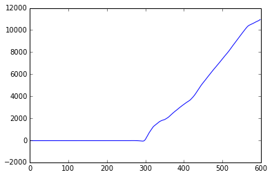

```python
def getTimeTakeOff(index):
    for index_value,value in enumerate(flight_list[index]['DATA']['ALT_STDC']):
        if value > 1:
            timeTakeOff = flight_list[index]['DATA']['T'][index_value]/8
            timeTakePlus = (timeTakeOff + (5*60))*8
            timeTakeMinus = (timeTakeOff - (5*60))*8
            break
    data = []
    for index_value,value in enumerate(flight_list[index]['DATA']['T']):
        if value > timeTakeMinus and value < timeTakePlus:
            data.append(flight_list[index]['DATA']['ALT_STDC'][index_value])
    plt.plot(data)

getTimeTakeOff(1)
```

**Question**: Using the clean dataset, detect the touch down phase of all flights (Touch_down_time). Highlight the phase by drawing the vertical trajectories between 5 minutes before and 5 minutes after the touch down time.

```
617112.125
```

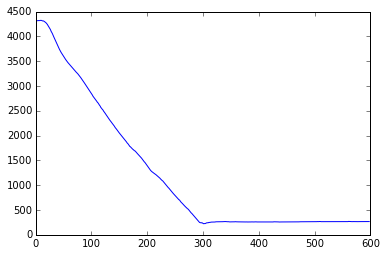

```python
def getTimeTouchDown(index):
    takeOff = False
    timeTakePlus2 = 0
    timeTakeMinus2 = 0
    for index_value,value in enumerate(flight_list[index]['DATA']['AIR_GROUND']):
        if value < 1:
            takeOff = True
        if value == True and takeOff == True:
            timeTakeOff = flight_list[index]['DATA']['T'][index_value]/8
            print(timeTakeOff)
            timeTakePlus2 = (timeTakeOff + (5*60))*8
            timeTakeMinus2 = (timeTakeOff - (5*60))*8
            break
    data = []
    for index_value,value in enumerate(flight_list[index]['DATA']['T']):
        if value > timeTakeMinus2 and value < timeTakePlus2:
            data.append(flight_list[index]['DATA']['ALT_STDC'][index_value])
    plt.plot(data)

getTimeTouchDown(1)
#plt.plot(flight_list[index]['DATA']['ALT_STD'])
```

Next, we want to detect the moment that the aircraft completed its climb (top of climb).

**Question**: Draw the vertical path of a minute before liftoff until five minutes after the top of climb. For information, a plane is considered: * in phase of climb if the altitude increases 30 m/second for 20 seconds * in stable phase if the altitude does not vary more than 30 m 5 minutes * in phase of descent if the altitude decreases 30 m/second for 20 seconds

```
38010.0
[-34.   0.   0. ...,   0.   0.   0.]
```

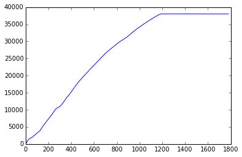

```python
#plt.plot(flight_list[index]['DATA']['ALT_STDC'])
import math
def getTimeTakeOff(index):
    timeTakePlus = 0
    timeTakeMinus = 0
    MAX = max(flight_list[index]['DATA']['ALT_STDC'])
    print(MAX)
    window = [1,-1]
    slope = np.convolve(flight_list[index]['DATA']['ALT_STDC'], window, mode='same') / (len(window) - 1)
    print(slope)
    data = []
    for index_value,value in enumerate(slope):
        if value > 20 :
            begin =index_value
            break
    for index_value,value in enumerate(slope[::-1]):
        if value < -40 :
            end = index_value
            break
    for index_value,value in enumerate(slope):
        if index_value > begin and index_value < end :
            data.append(flight_list[index]['DATA']['ALT_STDC'][index_value])
    plt.plot(data)


getTimeTakeOff(1)
```

**Question**: Similarly, detect the time when the aircraft begins its descent phase (top of descent).

```
38012.0
[ 34.   0.   0. ...,   0.   0.   0.]
```

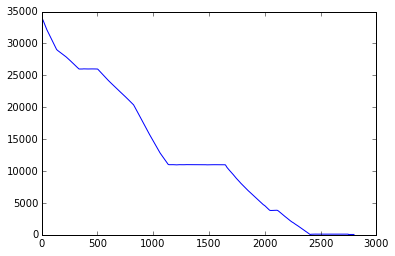

```python
#plt.plot(flight_list[index]['DATA']['ALT_STDC'])
import math
def getTimeTouchDwn(index):
    timeTakePlus = 0
    timeTakeMinus = 0
    MAX = max(flight_list[index]['DATA']['ALT_STDC'])
    print(MAX)
    window = [1,-1]
    slope = np.convolve(flight_list[index]['DATA']['ALT_STDC'], window, mode='same') / (len(window) - 1)
    print(slope)
    data = []
    for index_value,value in enumerate(slope):
        if value < -20 and index_value > len(slope)/2:
            begin =index_value
            break
    for index_value,value in enumerate(slope[::-1]):
        end = len(slope)
        if value > 30 and index_value < len(slope)/2:
            end = index_value
            break
    for index_value,value in enumerate(slope):
        if index_value > begin and index_value < end :
            data.append(flight_list[index]['DATA']['ALT_STDC'][index_value])
    plt.plot(data)


getTimeTouchDwn(0)
```

# 2.2 Detection of holding procedure

Sometimes, the aircraft does not landing directly to the destination airport, but performs one or more loops before landing. In these case, we name the waiting process "holding".

**Question**: Detect cases of holding in the data and draw the LAT, LON trajectories of these flights

```
38009.0
[ 135.   -1.    0. ...,    0.    0.    0.]
38010.0
[-34.   0.   0. ...,   0.   0.   0.]
38015.0
[ 47.   0.   0. ...,   0.   0.   0.]
```

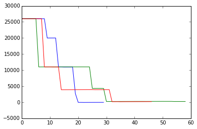

```python
def detectHoldingP(index):
    timeTakePlus = 0
    timeTakeMinus = 0
    MAX = max(flight_list[index]['DATA']['ALT_STDC'])
    print(MAX)
    window = [1,-1]
    slope = np.convolve(flight_list[index]['DATA']['ALT_STDC'], window, mode='same') / (len(window) - 1)
    print(slope)
    data = []
    for index_value,value in enumerate(slope):
        if value < -20 and index_value > len(slope)/2:
            begin =index_value
            break
    for index_value,value in enumerate(slope[::-1]):
        end = len(slope)
        if value > 30 and index_value < len(slope)/2:
            end = index_value
            break
    for index_value,value in enumerate(slope):
        if index_value > begin and index_value < end and value > 1:
            data.append(flight_list[index]['DATA']['ALT_STDC'][index_value])
    plt.plot(data)

detectHoldingP(50)
detectHoldingP(1)
detectHoldingP(9)
```

# 2.3 Determination of the departure and arrival airports

Note that the data that we are using in this notebook has been anonymized. This means that the trajectories of a flight have been modified to hide the real information about that flight. In particular, in the dataset we use in this notebook, trajectories have been modified by simple translation and rotation operations.

**Question**: Find the departure and destination airports of the flights in the dataset

# 2.4 Arrival procedures

**Question**: Perform a data clustering to group flight data according to the different arrival procedures a plane can take, and then display their trajectories in color.